# main

2024-12-05

## Загрузка данных

```r
data_path <- 'data/beta_1/'
load_file <- function(file) {
  temp_dt <- read.csv(str_c(data_path, file))
  temp_dt$id <- temp_dt[temp_dt$sender == 'Анкета', ]$id
  return(temp_dt)
}
dt <- do.call('rbind',
              data_path %>%
                list.files() %>%
                lapply(load_file)
)
dt <- dt %>%
        filter(sender == "Ответ *код") %>%
        select(id, interval, condition_direction, condition_image, order, prob_i, response,duration)
```

## Форматирование переменных

```r
dt$condition_direction <- dt$condition_direction %>% as.factor()
dt$condition_image <- dt$condition_image %>% as.factor()
dt$order <- dt$order %>% as.factor()
dt$id <- dt$id %>% as.factor()
#dt$interval <- dt$interval %>% as.factor()
```

## Отсев

```r
min <- mean(dt$duration) - (3*sd(dt$duration))
max <- mean(dt$duration) + (3*sd(dt$duration))

dt_dropout <- dt %>%
                  filter(duration > min & duration < max)

print('Отсев (проб)')
```

```
## [1] "Отсев (проб)"
```

```r
print(dt %>% nrow() - dt_dropout %>% nrow())
```

```
## [1] 25
```

## Смешанная модель - время реакции

Модель с взаимодействием предикторов направления исчезновения элементов и направление в картинках + порядок предъявления

```r
mix.duration.all <- lmer(duration ~ condition_direction*condition_image+order + (1|id), dt_dropout )
summary(mix.duration.all)
```

```
## Linear mixed model fit by REML. t-tests use Satterthwaite's method [
## lmerModLmerTest]
## Formula: duration ~ condition_direction * condition_image + order + (1 |
##     id)
##    Data: dt_dropout
##
## REML criterion at convergence: 104614.4
##
## Scaled residuals:
##     Min      1Q  Median      3Q     Max
## -1.5802 -0.4903 -0.2210  0.1273 10.5613
##
## Random effects:
##  Groups   Name        Variance Std.Dev.
##  id       (Intercept)  64791   254.5
##  Residual             637623   798.5
## Number of obs: 6455, groups:  id, 28
##
## Fixed effects:
##                                                                Estimate
## (Intercept)                                                      713.84
## condition_directioncounterclockwise                              196.51
## condition_imagearrow_right                                       -64.96
## condition_imagecurve                                             -76.65
## orderdesc                                                        -77.81
## condition_directioncounterclockwise:condition_imagearrow_right    78.91
## condition_directioncounterclockwise:condition_imagecurve          94.78
##                                                                Std. Error
## (Intercept)                                                         54.83
## condition_directioncounterclockwise                                 34.41
## condition_imagearrow_right                                          34.37
## condition_imagecurve                                                34.36
## orderdesc                                                           19.88
## condition_directioncounterclockwise:condition_imagearrow_right      48.65
## condition_directioncounterclockwise:condition_imagecurve            48.72
##                                                                     df t value
## (Intercept)                                                      41.75  13.019
## condition_directioncounterclockwise                            6420.98   5.711
## condition_imagearrow_right                                     6420.97  -1.890
## condition_imagecurve                                           6420.97  -2.231
## orderdesc                                                      6420.98  -3.915
## condition_directioncounterclockwise:condition_imagearrow_right 6420.98   1.622
## condition_directioncounterclockwise:condition_imagecurve       6420.99   1.946
##                                                                Pr(>|t|)
## (Intercept)                                                    2.73e-16 ***
## condition_directioncounterclockwise                            1.17e-08 ***
## condition_imagearrow_right                                       0.0588 .
## condition_imagecurve                                             0.0257 *
## orderdesc                                                      9.15e-05 ***
## condition_directioncounterclockwise:condition_imagearrow_right   0.1049
## condition_directioncounterclockwise:condition_imagecurve         0.0518 .
## ---
## Signif. codes:  0 '***' 0.001 '**' 0.01 '*' 0.05 '.' 0.1 ' ' 1
##
## Correlation of Fixed Effects:
##             (Intr) cndtn_d cndt__ cndtn_m ordrds cn_:__
## cndtn_drctn -0.313
## cndtn_mgrr_ -0.313  0.499
## cndtn_mgcrv -0.313  0.499   0.500
## orderdesc   -0.181 -0.001   0.000  0.000
## cndtn_dr:__  0.221 -0.707  -0.706 -0.353   0.000
## cndtn_drc:_  0.221 -0.706  -0.353 -0.705   0.001  0.500
```

модель где только направления движения + порядок

```r
mix.duration.cond_order <- lmer(duration ~ condition_direction+order + (1|id), dt_dropout )
summary(mix.duration.cond_order)
```

```
## Linear mixed model fit by REML. t-tests use Satterthwaite's method [
## lmerModLmerTest]
## Formula: duration ~ condition_direction + order + (1 | id)
##    Data: dt_dropout
##
## REML criterion at convergence: 104655.6
##
## Scaled residuals:
##     Min      1Q  Median      3Q     Max
## -1.5209 -0.4905 -0.2183  0.1197 10.5229
##
## Random effects:
##  Groups   Name        Variance Std.Dev.
##  id       (Intercept)  64790   254.5
##  Residual             637829   798.6
## Number of obs: 6455, groups:  id, 28
##
## Fixed effects:
##                                     Estimate Std. Error      df t value
## (Intercept)                           666.64      51.12   31.54  13.042
## condition_directioncounterclockwise   254.39      19.88 6424.99  12.795
## orderdesc                             -77.82      19.88 6424.98  -3.914
##                                     Pr(>|t|)
## (Intercept)                         3.00e-14 ***
## condition_directioncounterclockwise  < 2e-16 ***
## orderdesc                           9.17e-05 ***
## ---
## Signif. codes:  0 '***' 0.001 '**' 0.01 '*' 0.05 '.' 0.1 ' ' 1
##
## Correlation of Fixed Effects:
##             (Intr) cndtn_
## cndtn_drctn -0.194
## orderdesc   -0.194  0.000
```

```r
anova(mix.duration.cond_order, mix.duration.all)
```

```
## refitting model(s) with ML (instead of REML)
```

```
## Data: dt_dropout
## Models:
## mix.duration.cond_order: duration ~ condition_direction + order + (1 | id)
## mix.duration.all: duration ~ condition_direction * condition_image + order + (1 | id)
##                         npar    AIC    BIC logLik deviance  Chisq Df Pr(>Chisq)
## mix.duration.cond_order    5 104691 104725 -52340   104681
## mix.duration.all           9 104693 104754 -52337   104675 6.0816  4     0.1931
```

**модели значимо не отличаются, значит модель, где только направление стрелок + порядок лучше, потому что она компактней**

модель где предиктор взаимодействие двух направлений + порядок

```r
mix.duration.dirimg_order <- lmer(duration ~ condition_direction:condition_image+order + (1|id) + (1|interval), dt_dropout )
```

```
## fixed-effect model matrix is rank deficient so dropping 1 column / coefficient
```

```r
summary(mix.duration.dirimg_order)
```

```
## Linear mixed model fit by REML. t-tests use Satterthwaite's method [
## lmerModLmerTest]
## Formula: duration ~ condition_direction:condition_image + order + (1 |
##     id) + (1 | interval)
##    Data: dt_dropout
##
## REML criterion at convergence: 104440.8
##
## Scaled residuals:
##     Min      1Q  Median      3Q     Max
## -1.7526 -0.4784 -0.1967  0.1370 10.5976
##
## Random effects:
##  Groups   Name        Variance Std.Dev.
##  id       (Intercept)  64987   254.9
##  interval (Intercept)  22535   150.1
##  Residual             616270   785.0
## Number of obs: 6455, groups:  id, 28; interval, 18
##
## Fixed effects:
##                                                                Estimate
## (Intercept)                                                     929.918
## orderdesc                                                       -77.965
## condition_directionclockwise:condition_imagearrow_left         -215.993
## condition_directioncounterclockwise:condition_imagearrow_left   -19.335
## condition_directionclockwise:condition_imagearrow_right        -281.096
## condition_directioncounterclockwise:condition_imagearrow_right   -5.498
## condition_directionclockwise:condition_imagecurve              -292.638
##                                                                Std. Error
## (Intercept)                                                        65.192
## orderdesc                                                          19.542
## condition_directionclockwise:condition_imagearrow_left             33.902
## condition_directioncounterclockwise:condition_imagearrow_left      33.950
## condition_directionclockwise:condition_imagearrow_right            33.910
## condition_directioncounterclockwise:condition_imagearrow_right     33.926
## condition_directionclockwise:condition_imagecurve                  33.902
##                                                                      df t value
## (Intercept)                                                      55.755  14.264
## orderdesc                                                      6403.976  -3.990
## condition_directionclockwise:condition_imagearrow_left         6404.022  -6.371
```

[output cut: 38 more lines]

```
## orderdesc
## cndtn_drctnclckws:cndtn_mgrrw_l
## cndtn_drctncntrclckws:cndtn_mgrrw_l
## cndtn_drctnclckws:cndtn_mgrrw_r
## cndtn_drctncntrclckws:cndtn_mgrrw_r  0.503
## cndtn_drc:_                          0.503
##                                     cndtn_drctncntrclckws:cndtn_mgrrw_r
## orderdesc
## cndtn_drctnclckws:cndtn_mgrrw_l
## cndtn_drctncntrclckws:cndtn_mgrrw_l
## cndtn_drctnclckws:cndtn_mgrrw_r
## cndtn_drctncntrclckws:cndtn_mgrrw_r
## cndtn_drc:_                          0.503
## fit warnings:
## fixed-effect model matrix is rank deficient so dropping 1 column / coefficient
```

```r
anova(mix.duration.cond_order, mix.duration.dirimg_order)
```

```
## refitting model(s) with ML (instead of REML)
```

```
## Data: dt_dropout
## Models:
## mix.duration.cond_order: duration ~ condition_direction + order + (1 | id)
## mix.duration.dirimg_order: duration ~ condition_direction:condition_image + order + (1 | id) + (1 | interval)
##                           npar    AIC    BIC logLik deviance  Chisq Df
## mix.duration.cond_order      5 104691 104725 -52340   104681
## mix.duration.dirimg_order   10 104521 104589 -52251   104501 179.54  5
##                           Pr(>Chisq)
## mix.duration.cond_order
## mix.duration.dirimg_order  < 2.2e-16 ***
## ---
## Signif. codes:  0 '***' 0.001 '**' 0.01 '*' 0.05 '.' 0.1 ' ' 1
```

```r
mix.duration.order <- lmer(duration ~ order + (1|id), dt_dropout )
summary(mix.duration.order)
```

```
## Linear mixed model fit by REML. t-tests use Satterthwaite's method [
## lmerModLmerTest]
## Formula: duration ~ order + (1 | id)
##    Data: dt_dropout
##
## REML criterion at convergence: 104825.1
##
## Scaled residuals:
##     Min      1Q  Median      3Q     Max
## -1.6568 -0.4742 -0.2477  0.1136 10.2369
##
## Random effects:
##  Groups   Name        Variance Std.Dev.
##  id       (Intercept)  64527   254.0
##  Residual             653988   808.7
## Number of obs: 6455, groups:  id, 28
##
## Fixed effects:
##             Estimate Std. Error      df t value Pr(>|t|)
## (Intercept)   793.31      50.10   29.28  15.833 6.78e-16 ***
## orderdesc     -77.69      20.13 6425.98  -3.859 0.000115 ***
## ---
## Signif. codes:  0 '***' 0.001 '**' 0.01 '*' 0.05 '.' 0.1 ' ' 1
##
## Correlation of Fixed Effects:
##           (Intr)
## orderdesc -0.201
```

```r
anova(mix.duration.cond_order, mix.duration.order)
```

```
## refitting model(s) with ML (instead of REML)
```

```
## Data: dt_dropout
## Models:
## mix.duration.order: duration ~ order + (1 | id)
## mix.duration.cond_order: duration ~ condition_direction + order + (1 | id)
##                         npar    AIC    BIC logLik deviance  Chisq Df Pr(>Chisq)
## mix.duration.order         4 104851 104878 -52421   104843
## mix.duration.cond_order    5 104691 104725 -52340   104681 161.72  1  < 2.2e-16
##
## mix.duration.order
## mix.duration.cond_order ***
## ---
## Signif. codes:  0 '***' 0.001 '**' 0.01 '*' 0.05 '.' 0.1 ' ' 1
```

**Модели значимо отличаются, модель где есть предиктор направление появления движения - лучше. Так что оба эти предиктоар должны быть в модели.**

## Промежуточные итоги

| Порядок предъявления | Коэффициент (мс) |
| --- | --- |
| Нисходящее предъявления | 716 |
| Восходящее предъявления | 793 |

| Появление | Стимул | Коэффициент (мс) |
| --- | --- | --- |
| По часовой | Стрелки против часовой | 714 |
| По часовой | Стрелки по часовой | 649 |
| По часовой | Линии | 638 |
| Против часовой | Линии | 929 |
| Против часовой | Стрелки по часовой | 925 |
| Против часовой | Стрелки против часовой | 911 |

### Графики

```
## 'condition_image'. You can override using the `.groups` argument.
```

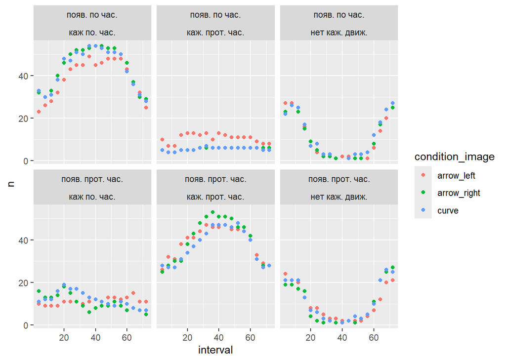

```r
graph_dt <- dt

graph_dt$condition_direction <- str_replace(graph_dt$condition_direction, 'counterclockwise', 'появ. прот. час.')
graph_dt$condition_direction <- str_replace(graph_dt$condition_direction, 'clockwise', 'появ. по час.')

graph_dt$response <- str_replace(graph_dt$response, 'counterclockwise', 'каж. прот. час.')
graph_dt$response <- str_replace(graph_dt$response, 'clockwise', 'каж по. час.')
graph_dt$response <- str_replace(graph_dt$response, 'down', 'нет каж. движ.')

graph_dt %>%
  group_by(interval, condition_direction, condition_image, response) %>%
  summarise(n = n()) %>%
  ggplot(aes(y = n, x = interval, color = condition_image))+
  geom_point()+
  facet_wrap(~ condition_direction + response)
```

```r
ggsave("график1_частота_ответов_при_разных_интервалах_и_стимульных_материалах.png")
```

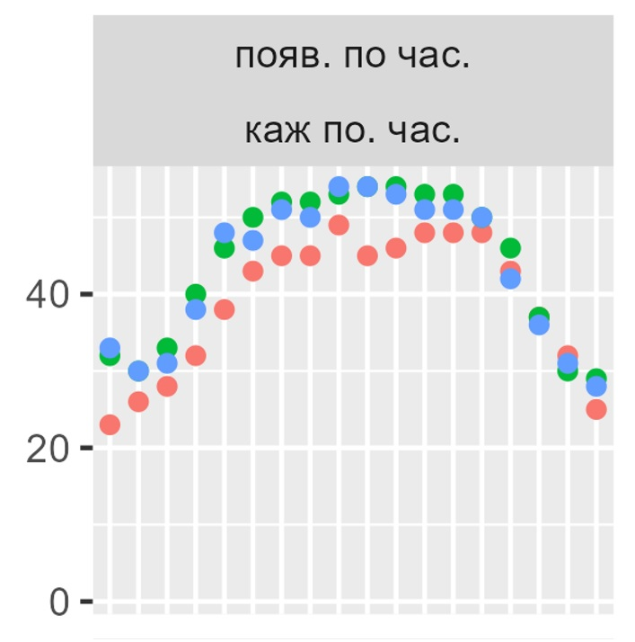

```r
#dt %>% ggplot(aes())
```

**Зелёное** - стрелки по часовой

**Красное** - стрелки против часовой

**Синие -** кривые

Реже всего отвечали, что кажется движение по часовой (когда стрелки предъявлились по часовой) при стрелках повёрнутых в лево, а чаще в право.

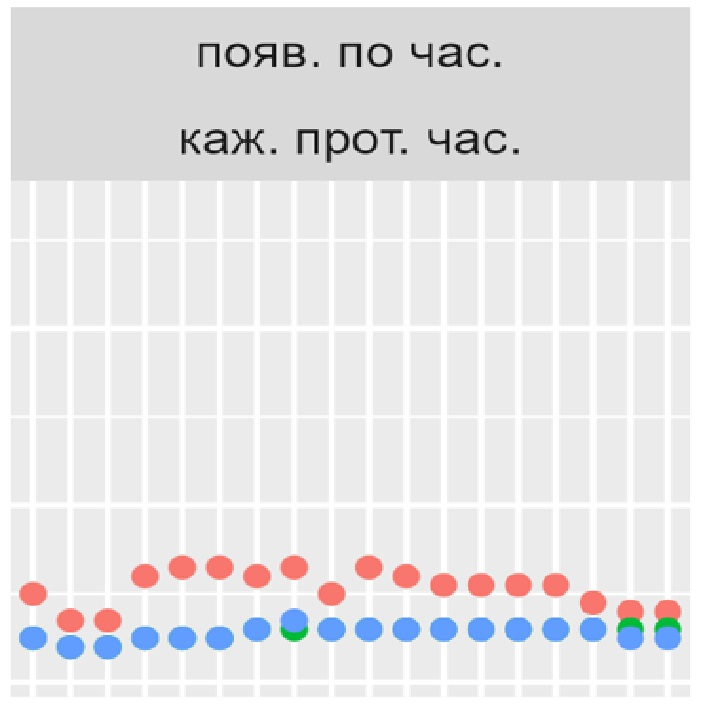

В случае, когда появление было по часовой, а люди отвечали, что оно против часовой (происходило достаточно редко) было для стрелок направленных влево.

На появление против часовой эти закономерности не направляются. Частота кажущегося движения по часовой, при появлении против часовой существенно больше, чем в обратном случае.

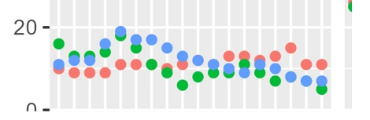

*Возможно* - у добровольцев есть ожидания, что движение должно быть по часовой стрелки - и это ожидание создаёт дополнительную дисперсию в данных. Действие этого ожидания может быть намного больше, чем действии стрелок в качестве стимульного материала.

```r
dt$response <- dt$response %>% as.factor()
dt$condition_image <- dt$condition_image %>% as.factor()
dt$order <- dt$order %>% as.factor()
```

На ранее представленных графиках видно, что если закономерность и есть - она существенно отличается для направления по часовойи против часовой. В связи с этим брались только пробы, где **появление элементов было по часовой (+ были убраны пробы - где был моторный конфликт - график 2)**, поскольку связь (если есть) имеет судя по графику не линейный характер были отсеины пробы с **интервалами больше 50**

```r
dt_cl_resp <- dt %>% filter(response != "counterclockwise")
dt_cl_resp <- dt_cl_resp %>% filter(condition_direction == "clockwise")
dt_cl_resp <- dt_cl_resp %>% filter(interval < 52)
dt_cl_resp$response <- as.numeric(dt_cl_resp$response == "clockwise")
dt_cl_resp$interval <- dt_cl_resp$interval %>% as.factor()

model_rn_dep_stim_type = glmer(response ~  interval+condition_image + (1|id)  + (1|order), family=binomial, data = dt_cl_resp)
summary(model_rn_dep_stim_type)
```

```
## Generalized linear mixed model fit by maximum likelihood (Laplace
##   Approximation) [glmerMod]
##  Family: binomial  ( logit )
## Formula: response ~ interval + condition_image + (1 | id) + (1 | order)
##    Data: dt_cl_resp
##
##      AIC      BIC   logLik deviance df.resid
##    777.6    866.4   -372.8    745.6     1882
##
## Scaled residuals:
##      Min       1Q   Median       3Q      Max
## -233.633    0.007    0.047    0.179    7.211
##
## Random effects:
##  Groups Name        Variance Std.Dev.
##  id     (Intercept) 3.115    1.765
##  order  (Intercept) 5.981    2.446
## Number of obs: 1898, groups:  id, 28; order, 2
##
## Fixed effects:
##                             Estimate Std. Error z value Pr(>|z|)
## (Intercept)                 0.615095   1.789290   0.344 0.731023
## interval8                  -0.389308   0.367492  -1.059 0.289433
## interval12                  0.007555   0.362284   0.021 0.983363
## interval16                  1.232353   0.361782   3.406 0.000658 ***
## interval20                  2.671455   0.392465   6.807 9.97e-12 ***
## interval24                  3.359012   0.427020   7.866 3.66e-15 ***
## interval28                  4.561901   0.543656   8.391  < 2e-16 ***
## interval32                  4.770659   0.574370   8.306  < 2e-16 ***
## interval36                  6.900842   0.960150   7.187 6.61e-13 ***
## interval40                  6.857043   0.968398   7.081 1.43e-12 ***
## interval44                  6.254776   0.823545   7.595 3.08e-14 ***
## interval48                  5.405272   0.661336   8.173 3.00e-16 ***
## condition_imagearrow_right  0.501434   0.247628   2.025 0.042873 *
## condition_imagecurve        0.273913   0.244879   1.119 0.263325
## ---
## Signif. codes:  0 '***' 0.001 '**' 0.01 '*' 0.05 '.' 0.1 ' ' 1
```

```
##
## Correlation matrix not shown by default, as p = 14 > 12.
## Use print(value, correlation=TRUE)  or
##     vcov(value)        if you need it
```

```
## optimizer (Nelder_Mead) convergence code: 0 (OK)
## Model failed to converge with max|grad| = 0.0697603 (tol = 0.002, component 1)
```

```r
dt_cl_resp <- dt %>% filter(response != "clockwise")
dt_cl_resp <- dt_cl_resp %>% filter(condition_direction == "counterclockwise")
dt_cl_resp <- dt_cl_resp %>% filter(interval < 52)
dt_cl_resp <- within(dt_cl_resp, condition_image <- relevel(condition_image, ref = 2))
dt_cl_resp$response <- as.numeric(dt_cl_resp$response == "counterclockwise")
dt_cl_resp$interval <- dt_cl_resp$interval %>% as.factor()

model_ln_dep_stim = glmer(response ~ interval+condition_image + (1|id) + (1|order), family=binomial, data = dt_cl_resp)
summary(model_ln_dep_stim)
```

```
## Generalized linear mixed model fit by maximum likelihood (Laplace
##   Approximation) [glmerMod]
##  Family: binomial  ( logit )
## Formula: response ~ interval + condition_image + (1 | id) + (1 | order)
##    Data: dt_cl_resp
##
##      AIC      BIC   logLik deviance df.resid
##    844.1    931.4   -406.1    812.1     1711
##
## Scaled residuals:
##      Min       1Q   Median       3Q      Max
## -29.5003   0.0234   0.0992   0.2421   8.0724
##
## Random effects:
##  Groups Name        Variance Std.Dev.
##  id     (Intercept) 1.438    1.199
##  order  (Intercept) 3.839    1.959
## Number of obs: 1727, groups:  id, 28; order, 2
##
## Fixed effects:
##                           Estimate Std. Error z value Pr(>|z|)
## (Intercept)                 0.6995     1.4329   0.488  0.62541
## interval8                   0.2825     0.3431   0.823  0.41024
## interval12                  0.3636     0.3428   1.061  0.28882
## interval16                  1.1236     0.3525   3.187  0.00144 **
## interval20                  2.4879     0.4048   6.145 7.98e-10 ***
## interval24                  2.9245     0.4178   7.001 2.55e-12 ***
## interval28                  3.8103     0.4841   7.871 3.51e-15 ***
## interval32                  4.6173     0.5771   8.000 1.24e-15 ***
## interval36                  4.8847     0.6184   7.899 2.81e-15 ***
## interval40                  4.8511     0.6183   7.846 4.30e-15 ***
## interval44                  4.9717     0.6192   8.029 9.82e-16 ***
## interval48                  4.3223     0.5136   8.415  < 2e-16 ***
## condition_imagearrow_left  -0.2922     0.2365  -1.235  0.21670
## condition_imagecurve       -0.3947     0.2395  -1.648  0.09931 .
## ---
## Signif. codes:  0 '***' 0.001 '**' 0.01 '*' 0.05 '.' 0.1 ' ' 1
```

```
##
## Correlation matrix not shown by default, as p = 14 > 12.
## Use print(value, correlation=TRUE)  or
##     vcov(value)        if you need it
```

```
## optimizer (Nelder_Mead) convergence code: 0 (OK)
## Model failed to converge with max|grad| = 0.0330542 (tol = 0.002, component 1)
```

## Результаты смешанной логистической регрессии

**Интервалы 4 - 52**

| Значение переменной | Условие | Значен. коэф. / Ст. ошибка | P |
| --- | --- | --- | --- |
| Появление по часовой / ответ - стрелка в право или нет движения | Стрелки вправо | 0.5 / 0.24 | **0.042** |
| Появление по часовой / ответ - стрелка в право или нет движения | Кривые | 0.27 / 0.24 | 0.26 |
| Появление против часовой / ответ - стрелка в влево или нет движения | Стрелки влево | -0.29 / 0.23 | 0.21 |
| Появление против часовой / ответ - стрелки в лево или нет движения | Кривые | -0.39 / 0.23 | 0.09 |

Взаимодействие между переменной интервалы и тип стимулов таким образом обнаружить сложно, в связи с маленьким количество проб и большой объёмностью модели.

Интервал в котором приемущественно происходит восприятие кажущегося движения - с 16 мс по 56 мс.

## Сравнение между конкретными интервалами (маленькие интервалы)

Берутся интервалы и идёт попарное сравнение между конкретными интервалами

```r
dt_cl_resp <- dt %>% filter(response != "counterclockwise")
dt_cl_resp <- dt_cl_resp %>% filter(condition_direction == "clockwise")
dt_cl_resp <- dt_cl_resp %>% filter(interval == 8 | interval == 12 | interval == 16 | interval == 20)
dt_cl_resp$response <- as.numeric(dt_cl_resp$response == "clockwise")
dt_cl_resp$interval <- dt_cl_resp$interval %>% as.factor()
```

```r
model_ln_dep_stim = glmer(response ~ interval*condition_image + (1|id) + (1|order), family=binomial, data = dt_cl_resp)
summary(model_ln_dep_stim)
```

```
## Generalized linear mixed model fit by maximum likelihood (Laplace
##   Approximation) [glmerMod]
##  Family: binomial  ( logit )
## Formula: response ~ interval * condition_image + (1 | id) + (1 | order)
##    Data: dt_cl_resp
##
##      AIC      BIC   logLik deviance df.resid
##    358.3    420.9   -165.2    330.3      631
##
## Scaled residuals:
##     Min      1Q  Median      3Q     Max
## -3.5124 -0.1831  0.0196  0.1100 24.9459
##
## Random effects:
##  Groups Name        Variance Std.Dev.
##  id     (Intercept)  7.696   2.774
##  order  (Intercept) 16.944   4.116
## Number of obs: 645, groups:  id, 28; order, 2
##
## Fixed effects:
##                                       Estimate Std. Error z value Pr(>|z|)
## (Intercept)                             0.7464     3.0400   0.246  0.80603
## interval12                              0.7418     0.9087   0.816  0.41430
## interval16                              2.4858     0.9026   2.754  0.00589 **
## interval20                              4.2057     0.9432   4.459 8.24e-06 ***
## condition_imagearrow_right              0.5180     0.9184   0.564  0.57274
## condition_imagecurve                    0.5312     0.9165   0.580  0.56219
## interval12:condition_imagearrow_right   0.2755     1.2218   0.225  0.82161
## interval16:condition_imagearrow_right   0.2662     1.1627   0.229  0.81890
## interval20:condition_imagearrow_right  -0.0751     1.1846  -0.063  0.94945
## interval12:condition_imagecurve        -0.3739     1.2469  -0.300  0.76427
## interval16:condition_imagecurve        -0.1913     1.1641  -0.164  0.86948
## interval20:condition_imagecurve         0.4533     1.2010   0.377  0.70585
## ---
## Signif. codes:  0 '***' 0.001 '**' 0.01 '*' 0.05 '.' 0.1 ' ' 1
##
## Correlation of Fixed Effects:
##             (Intr) intr12 intr16 intr20 cndt__ cndtn_ i12:__ i16:__ i20:__
## interval12  -0.150
## interval16  -0.148  0.573
```

[output cut: 8 more lines]

```
## intrvl20:c_  0.117 -0.406 -0.426 -0.675 -0.406 -0.761  0.296  0.322  0.532
##             in12:_ in16:_
## interval12
## interval16
## interval20
## cndtn_mgrr_
## cndtn_mgcrv
## intrvl12:__
## intrvl16:__
## intrvl20:__
## intrvl12:c_
## intrvl16:c_  0.572
## intrvl20:c_  0.553  0.600
## optimizer (Nelder_Mead) convergence code: 0 (OK)
## Model failed to converge with max|grad| = 0.0288858 (tol = 0.002, component 1)
```

Если брать только 12, 16, 20 - интервалы, где и происходит переход между частотой распознавания движения и не распознавания движения - то видно, что ни тип стрелок ни взаимодействие придкторов не значимы, значение коэффициентов меньше чем стандартная ошика, это может быть связанно с маленьким коилчеством проб, а может окно не раздвигается.

## Сравнение между конкретными интервалами (большие интервалы)

```r
dt_cl_resp <- dt %>% filter(response != "counterclockwise")
dt_cl_resp <- dt_cl_resp %>% filter(condition_direction == "clockwise")
dt_cl_resp <- dt_cl_resp %>% filter(interval == 64 | interval == 68 | interval == 72)
dt_cl_resp$response <- as.numeric(dt_cl_resp$response == "clockwise")
dt_cl_resp$interval <- dt_cl_resp$interval %>% as.factor()
```

```r
model_ln_dep_stim = glmer(response ~ interval*condition_image + (1|id) + (1|order), family=binomial, data = dt_cl_resp)
summary(model_ln_dep_stim)
```

```
## Generalized linear mixed model fit by maximum likelihood (Laplace
##   Approximation) [glmerMod]
##  Family: binomial  ( logit )
## Formula: response ~ interval * condition_image + (1 | id) + (1 | order)
##    Data: dt_cl_resp
##
##      AIC      BIC   logLik deviance df.resid
##    268.8    314.8   -123.4    246.8      470
##
## Scaled residuals:
##    Min     1Q Median     3Q    Max
## -2.968 -0.226  0.028  0.123 35.607
##
## Random effects:
##  Groups Name        Variance Std.Dev.
##  id     (Intercept)  5.723   2.392
##  order  (Intercept) 15.924   3.990
## Number of obs: 481, groups:  id, 27; order, 2
##
## Fixed effects:
##                                        Estimate Std. Error z value Pr(>|z|)
## (Intercept)                            3.684040   2.936009   1.255 0.209559
## interval68                            -1.489655   0.773156  -1.927 0.054015 .
## interval72                            -3.272037   0.889406  -3.679 0.000234 ***
## condition_imagearrow_right            -0.631623   0.740383  -0.853 0.393603
## condition_imagecurve                  -0.678976   0.735157  -0.924 0.355705
## interval68:condition_imagearrow_right -0.661488   1.104037  -0.599 0.549070
## interval72:condition_imagearrow_right  0.754722   1.149238   0.657 0.511365
## interval68:condition_imagecurve        0.004333   1.078394   0.004 0.996794
## interval72:condition_imagecurve        0.719769   1.151318   0.625 0.531860
## ---
## Signif. codes:  0 '***' 0.001 '**' 0.01 '*' 0.05 '.' 0.1 ' ' 1
##
## Correlation of Fixed Effects:
##             (Intr) intr68 intr72 cndt__ cndtn_ i68:__ i72:__ in68:_
## interval68  -0.144
## interval72  -0.155  0.468
## cndtn_mgrr_ -0.136  0.499  0.443
## cndtn_mgcrv -0.135  0.499  0.442  0.511
## intrvl68:__  0.073 -0.660 -0.243 -0.662 -0.335
## intrvl72:__  0.086 -0.318 -0.676 -0.640 -0.327  0.426
## intrvl68:c_  0.086 -0.687 -0.282 -0.346 -0.678  0.483  0.222
## intrvl72:c_  0.085 -0.317 -0.674 -0.325 -0.636  0.213  0.513  0.434
## optimizer (Nelder_Mead) convergence code: 0 (OK)
## Model failed to converge with max|grad| = 0.00955563 (tol = 0.002, component 1)
```

С поздними интервалами также не видно значимого вклада типа стимульного материала в ответ о видимости движения.

Возможно это связано с маленьким количеством проб для анализа.

## Загрузка данных

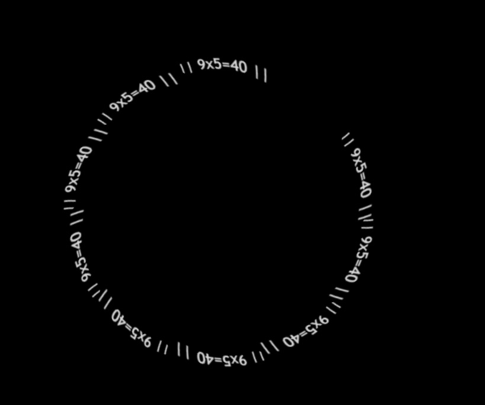

```r
data_path_2 <- 'data/beta_2_example/'
load_file <- function(file) {
  temp_dt <- read.csv(str_c(data_path_2, file))
  temp_dt$id <- file
  return(temp_dt)
}
dt_ex <- do.call('rbind',
              data_path_2 %>%
                list.files() %>%
                lapply(load_file)
)
```

Присвоение ответам стимулов которые там были

```r
dt_ex_new <- dt_ex %>% filter(sender == "Фиксационный крест" | sender == "Ответ *код")
dt_ex_new <- dt_ex_new %>% filter(!is.na(prob_i))
dt_ex_1 <- dt_ex_new %>% filter(sender == "Ответ *код")
dt_ex_2 <- dt_ex_new %>% filter(sender == "Фиксационный крест")

dt_ex_1$stimul <- dt_ex_2$stimul
```

Корректировка названий стимулов

```r
dt_ex_1$stimul <- dt_ex_1$stimul %>% str_replace('.png', '')
dt_ex_1$stimul <- dt_ex_1$stimul %>% str_replace('_', '=')
dt_ex_1$stimul <- dt_ex_1$stimul %>% str_replace('x', '*')
dt_ex_1$condition <- "neutral"
```

Подсчёт правильных ответов и сравнение их с ответами в названии

```r
(dt_ex_1[dt_ex_1$stimul != "e*ample=netral", ]$stimul %>% str_split('=', simplify = TRUE)) -> dt_ex_splited
examples <- dt_ex_splited[, 1]
dt_ex_1$stimul_answer = 0
dt_ex_1[dt_ex_1$stimul != "e*ample=netral", ]$stimul_answer <-
  examples %>% lapply( function(i) {eval(parse(text = i))}) %>% unlist()

dt_ex_1[dt_ex_1$stimul != "e*ample=netral", ]$condition <- as.numeric(dt_ex_splited[, 2]) == dt_ex_1[dt_ex_1$stimul != "e*ample=netral", ]$stimul_answer
```

Подготовка данных для модели

```r
dt_ex_1$response <- as.numeric(dt_ex_1$response == 'motion')
dt_ex_1$response <- dt_ex_1$response %>% as.factor()

dt_ex_1$interval <- dt_ex_1$interval %>% as.factor()

dt_ex_1$condition <- dt_ex_1$condition %>% as.factor()
```

### Результаты смешанной логистической регрессии

```r
model_resp_dep_cond = glmer(response ~ interval + condition + (1|id) + (1|stimul)+ (1|order), family=binomial, data = dt_ex_1)
summary(model_resp_dep_cond)
```

```
## Generalized linear mixed model fit by maximum likelihood (Laplace
##   Approximation) [glmerMod]
##  Family: binomial  ( logit )
## Formula: response ~ interval + condition + (1 | id) + (1 | stimul) + (1 |
##     order)
##    Data: dt_ex_1
##
##      AIC      BIC   logLik deviance df.resid
##    990.6   1080.6   -476.3    952.6      821
##
## Scaled residuals:
##     Min      1Q  Median      3Q     Max
## -2.9782 -0.7732  0.3938  0.6620  4.5883
##
## Random effects:
##  Groups Name        Variance  Std.Dev.
##  stimul (Intercept) 5.751e-08 0.0002398
##  id     (Intercept) 1.053e+00 1.0260343
##  order  (Intercept) 3.107e-08 0.0001763
## Number of obs: 840, groups:  stimul, 19; id, 5; order, 2
##
## Fixed effects:
##                  Estimate Std. Error z value Pr(>|z|)
## (Intercept)      -1.01714    0.56047  -1.815 0.069557 .
## interval16        0.27981    0.40773   0.686 0.492542
## interval20        0.25019    0.40951   0.611 0.541245
## interval24        0.79880    0.40696   1.963 0.049667 *
## interval28        1.30011    0.41500   3.133 0.001732 **
## interval32        2.18310    0.45325   4.817 1.46e-06 ***
## interval36        1.71655    0.42910   4.000 6.32e-05 ***
## interval40        1.70180    0.42857   3.971 7.16e-05 ***
## interval44        1.88752    0.43476   4.341 1.42e-05 ***
## interval48        1.50518    0.42177   3.569 0.000359 ***
## interval52        1.61009    0.42449   3.793 0.000149 ***
## interval56        1.00689    0.40939   2.459 0.013913 *
## interval60        0.14109    0.40946   0.345 0.730411
## interval64        0.31954    0.40954   0.780 0.435252
## conditionneutral -0.08253    0.19925  -0.414 0.678734
## conditionTRUE     0.37098    0.19887   1.865 0.062116 .
## ---
## Signif. codes:  0 '***' 0.001 '**' 0.01 '*' 0.05 '.' 0.1 ' ' 1
```

```
##
## Correlation matrix not shown by default, as p = 16 > 12.
## Use print(value, correlation=TRUE)  or
##     vcov(value)        if you need it
```

```
## optimizer (Nelder_Mead) convergence code: 0 (OK)
## Model failed to converge with max|grad| = 0.00230829 (tol = 0.002, component 1)
```

```r
graph_dt_2 <- dt_ex_1

graph_dt_2$condition_direction <- graph_dt_2$condition_direction %>% str_replace( 'counterclockwise', 'появ. прот. час.')
graph_dt_2$condition_direction <- graph_dt_2$condition_direction %>% str_replace('clockwise', 'появ. по час.')

graph_dt_2$response <- graph_dt_2$response %>% droplevels() %>%  as.character()
graph_dt_2$response <- graph_dt_2$response %>% str_replace("0", "нет каж. движ.")
graph_dt_2$response <- graph_dt_2$response %>% str_replace("1", "есть каж. движ.")

graph_dt_2$condition_direction <- graph_dt_2$condition_direction %>% as.factor()
graph_dt_2$interval <- graph_dt_2$interval %>% as.factor()
```

### График

```
## 'condition'. You can override using the `.groups` argument.
```

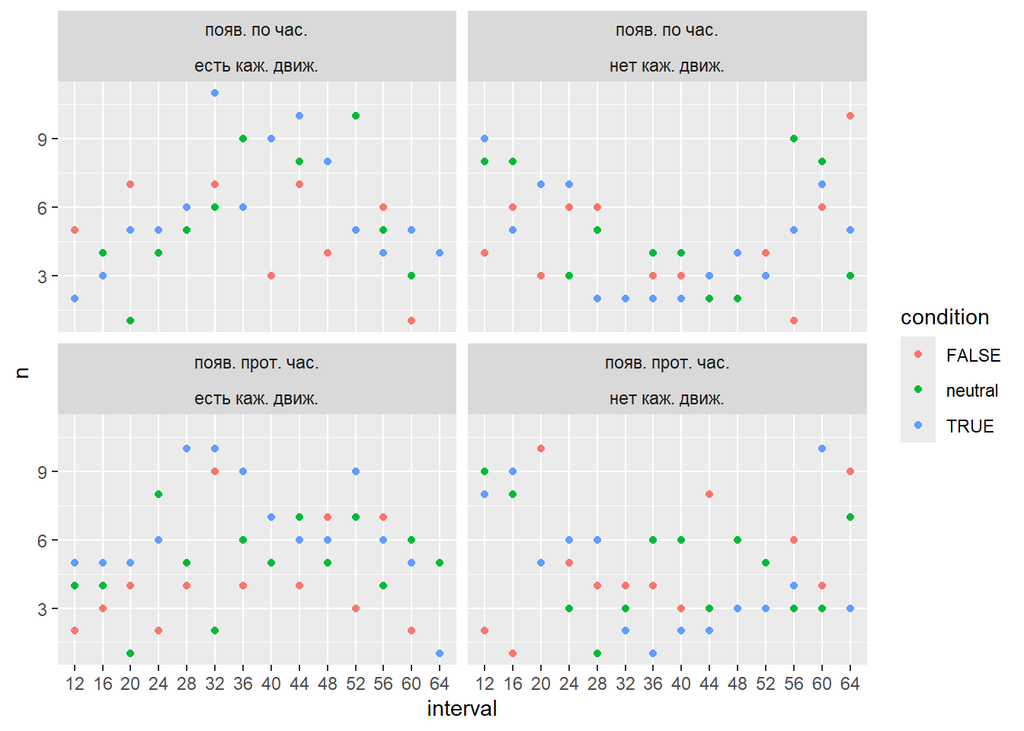

```r
graph_dt_2 %>%
  group_by(interval, condition_direction, condition, response) %>%
  summarise(n = n()) %>%
  ggplot(aes(y = n, x = interval, color = condition))+
  geom_point()+
  facet_wrap(~ condition_direction + response)
```

```r
ggsave("график2_частота_ответов_при_разных_интервалах_и_стимульных_материалах.png")
```

**По поводу движения, видно 0.06. Как будто бы есть тенденция к тому, что если правильный пример, люди чаще отвечают, что было движение.**

Частота разных условий

```r
dt_ex_1$condition %>% table()
```

```
## .
##   FALSE neutral    TRUE
##     257     283     300
```

```r
table(dt_ex_1$condition, dt_ex_1$response)
```

```
##
##             0   1
##   FALSE   124 133
##   neutral 136 147
##   TRUE    127 173
```

Плоховато сбалансировано, условий правильных впринципе чуть больше. Видно что пропорция в определённую сторону, но нужно выравнять количество.